# The Prosper Loan Data Project

## by Abimbola Akinjobi

## Investigation Overview

> This project looked at the prosper Loan dataset by investigating the relationship between borrower's interest rate with other variables and also look at employment and loan status metric. Key insights included:
> 1. Average BorrowerRate is 0.2
> 2. Average Loan amount is $8337.01
> 3. Employed individuals have the highest loans especially current employed individuals are more likely to apply for and receive loans.
> 4. Current loans are the highest of all loan status
> 5. As the loan amount and credit rating increases, the Borrower rate reduces

> Overall, the borrower's rate were greatly impacted by ratings and loan amount with employed individuals having the highest amount of loan.

## Dataset Overview

> The prosper Loan dataset was used for this project. The dataset had details about loans disbursed including loan amount, borrower rate (or interest rate), current loan status, employment status e.t.c. The prosper loan dataset has 113,937 rows of data and 81 columns. Some modifications were made to the dataset using the variabale definition as a guide. The dataset was modified further by selecting columns that was needed for the analysis.

## (Visualization 1)

> What is the distribution of employment status? Employed individuals have the highest frequency of employment status.

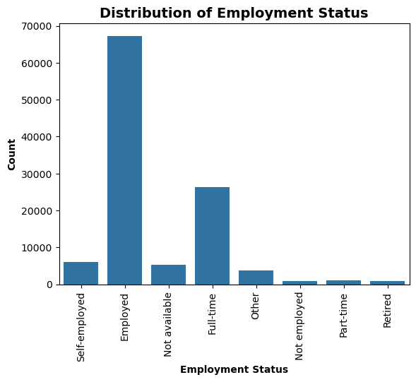

## (Visualization 2)

> There are more active loans than any other type of loans followed by completed loans

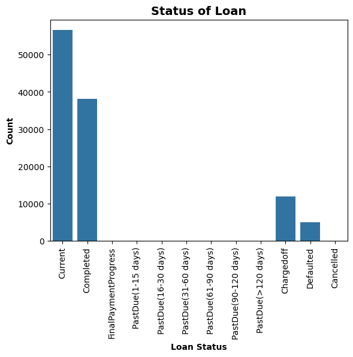

## (Visualization 3)

> Prosper rating C had the highest frequency followed by B

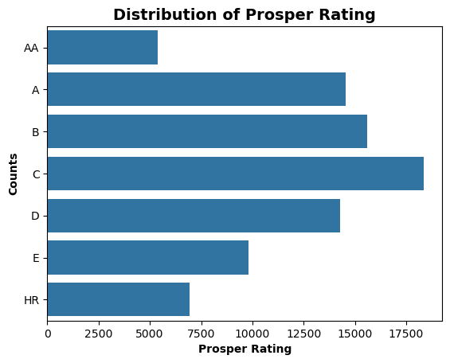

## (Visualization 4)

```
Mean loan amount:  $8337.01
```

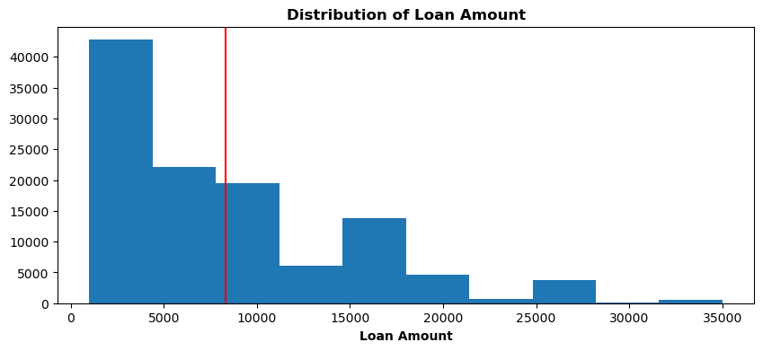

## (Visualization 5)

```
Average interest rate:  0.2
```

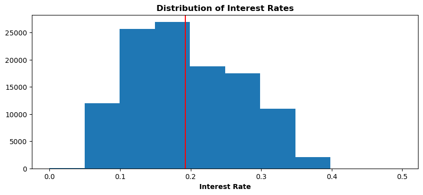

## (Visualization 6)

> This Borrower's Interest Rate is negatively correlated with loan amount. As the loan amount increases, the Borrower rate reduces which could be a strategy to get more loans disbursed.

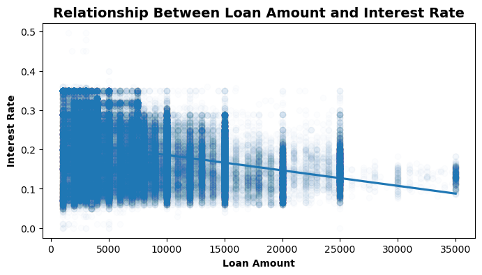

## (Visualization 7)

> As the credit increases, the Borrower's interest rate reduces. This means higher credit rating means borrower is less likely to default

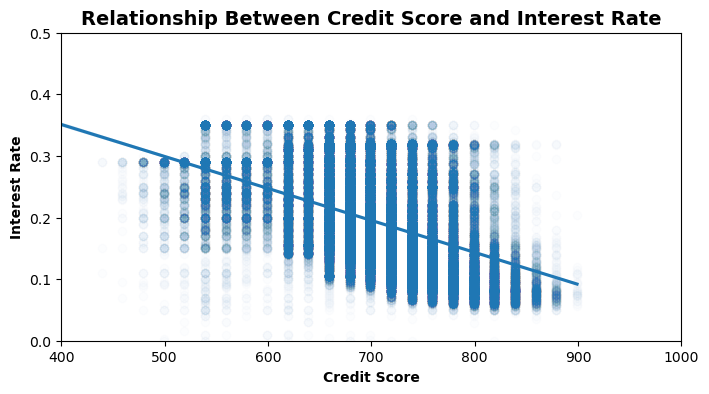

## (Visualization 8)

> As the borrower's credit score increases, the interest rate decreases which further solidifies our findings.

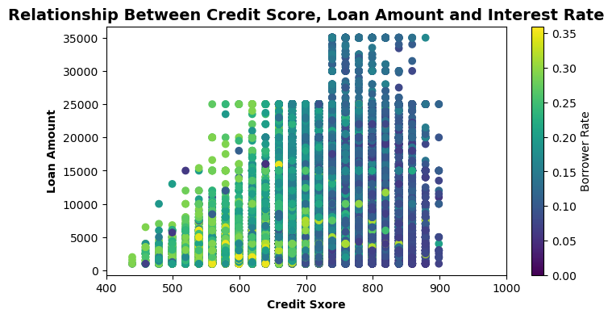

## Conclusion

> Overall, employed individuals have the highest current loan and the borrower's rate are influenced by credit score and loan amount.